# Assignment 5

Kaggle Competition and Unsupervised Learning

Aesha Gandhi 2026-03-26

# Imports/Setup

```python
# ignore warnings
import warnings
warnings.filterwarnings('ignore')
```

```python
# # mount drive
# from google.colab import drive
# drive.mount('/content/drive')
```

```python
!pip install -q jupyter_black
import jupyter_black

jupyter_black.load()
jupyter_black.load(line_length=79)

# <div style="page-break-before: always;"></div>
```

```python
# installs
!pip install xgboost lightgbm optuna -q
```

```
   ━━━━━━━━━━━━━━━━━━━━━━━━━━━━━━━━━━━━━━━━ 419.5/419.5 kB 8.3 MB/s eta 0:00:00
```

```python
# imports
import pandas as pd
import numpy as np
import pickle
import numpy as np
import pandas as pd
import matplotlib.pyplot as plt
import time

from sklearn.model_selection import train_test_split
from sklearn.impute import SimpleImputer
from sklearn.preprocessing import StandardScaler
from sklearn.metrics import (
    accuracy_score,
    roc_auc_score,
    average_precision_score,
    roc_curve,
    precision_recall_curve
)
from sklearn.linear_model import LogisticRegression
from sklearn.neighbors import KNeighborsClassifier
from sklearn.ensemble import RandomForestClassifier, GradientBoostingClassifier
from sklearn.svm import SVC
from sklearn.neural_network import MLPClassifier
from sklearn.ensemble import GradientBoostingClassifier
from sklearn.model_selection import GridSearchCV, StratifiedKFold
from xgboost import XGBClassifier
import lightgbm as lgb
import optuna
from xgboost import XGBClassifier
from sklearn.ensemble import StackingClassifier
from sklearn.linear_model import LogisticRegression as LR

from sklearn.impute import SimpleImputer
from sklearn.preprocessing import StandardScaler
from sklearn.linear_model import LogisticRegression
from sklearn.neighbors import KNeighborsClassifier
from sklearn.ensemble import RandomForestClassifier, GradientBoostingClassifier
```

# Exercise 1: Kaggle

## 1.2: Preprocess Data

```python
################################
# Load the data
################################
data = pd.read_pickle("/content/drive/MyDrive/Duke-MIDS/ML/HW5/data/a5_q1.pkl")

y_train = data['y_train']
X_train_original = data['X_train'] # Original dataset
X_train_ohe = data['X_train_ohe']  # One-hot-encoded dataset

X_test_original = data['X_test']
X_test_ohe = data['X_test_ohe']

################################
# Produce submission
################################

def create_submission(confidence_scores, save_path):
    '''Creates an output file of submissions for Kaggle

    Parameters
    ----------
    confidence_scores : list or numpy array
        Confidence scores (from predict_proba methods from classifiers) or
        binary predictions (only recommended in cases when predict_proba is
        not available)
    save_path : string
        File path for where to save the submission file.

    Example:
    create_submission(my_confidence_scores, './data/submission.csv')

    '''
    submission = pd.DataFrame({"score":confidence_scores})
    submission.to_csv(save_path, index_label="id")
```

```python
# feature engineering - add total guests, total nights, total costs, booking changes, is family?
def add_features(df):
    df = df.copy()

    df["total_guests"] = (
        df["adults"] +
        df["children"].fillna(0) +
        df["babies"]
    )

    df["total_nights"] = (
        df["stays_in_weekend_nights"] +
        df["stays_in_week_nights"]
    )

    df["total_cost"] = df["adr"] * df["total_nights"]

    df["booking_changes_ratio"] = (
        df["booking_changes"] / (df["lead_time"] + 1)
    )

    df["is_family"] = (
        (df["children"].fillna(0) + df["babies"]) > 0
    ).astype(int)

    df = df.drop(columns=["agent", "company"], errors="ignore")
    return df

# data preprocessing
# one hot encode features

X_train = add_features(X_train_ohe).copy()
X_test = add_features(X_test_ohe).copy()
y_train = y_train.copy()

# inspect data
print("X_train shape:", X_train.shape)
print("X_test shape:", X_test.shape)
print("y_train shape:", y_train.shape)

print("\nMissing values in training data:")
print(X_train.isnull().sum().sort_values(ascending=False).head(10))

print("\nMissing values in test data:")
print(X_test.isnull().sum().sort_values(ascending=False).head(10))

# check if duplicated rows in training data
print("\nDuplicate rows in X_train:", X_train.duplicated().sum())

# split data into training and validation
X_train_split, X_val, y_train_split, y_val = train_test_split(
    X_train,
    y_train,
    test_size=0.2,
    random_state=42,
    stratify=y_train
)

print("\nAfter validation split:")
print("X_train_split:", X_train_split.shape)
print("X_val:", X_val.shape)

# look at missing values and use median imputation

imputer = SimpleImputer(strategy="median")

X_train_imputed = pd.DataFrame(
    imputer.fit_transform(X_train_split),
    columns=X_train_split.columns,
    index=X_train_split.index
)

X_val_imputed = pd.DataFrame(
    imputer.transform(X_val),
    columns=X_val.columns,
    index=X_val.index
)

X_test_imputed = pd.DataFrame(
    imputer.transform(X_test),
    columns=X_test.columns,
    index=X_test.index
)


# normalize and standardize features
scaler = StandardScaler()

X_train_scaled = pd.DataFrame(
    scaler.fit_transform(X_train_imputed),
    columns=X_train_imputed.columns,
    index=X_train_imputed.index
)

X_val_scaled = pd.DataFrame(
    scaler.transform(X_val_imputed),
    columns=X_val_imputed.columns,
    index=X_val_imputed.index
)

X_test_scaled = pd.DataFrame(
    scaler.transform(X_test_imputed),
    columns=X_test_imputed.columns,
    index=X_test_imputed.index
)


print("\nAny missing values left?")
print("Train:", X_train_scaled.isnull().sum().sum())
print("Val:", X_val_scaled.isnull().sum().sum())
print("Test:", X_test_scaled.isnull().sum().sum())

print("\nFinished preprocessing.")
print("Scaled train shape:", X_train_scaled.shape)
print("Scaled val shape:", X_val_scaled.shape)
print("Scaled test shape:", X_test_scaled.shape)
```

```
X_train shape: (95512, 945)
X_test shape: (23878, 945)
y_train shape: (95512,)

Missing values in training data:
children        2
company_67.0    0
company_68.0    0
company_71.0    0
company_72.0    0
company_73.0    0
company_76.0    0
company_77.0    0
company_78.0    0
company_80.0    0
dtype: int64

Missing values in test data:
children        2
company_67.0    0
company_68.0    0
company_71.0    0
company_72.0    0
company_73.0    0
company_76.0    0
company_77.0    0
company_78.0    0
company_80.0    0
dtype: int64

Duplicate rows in X_train: 24648

After validation split:
X_train_split: (76409, 945)
X_val: (19103, 945)

Any missing values left?
Train: 0
Val: 0
Test: 0

Finished preprocessing.
Scaled train shape: (76409, 945)
Scaled val shape: (19103, 945)
Scaled test shape: (23878, 945)
```

The data was already provided as one hot encoded which was important for transforming categorical data into features we can use for models. The data is split into training and validation sets with stratification so that the class distirbution is preserved. I handle missing values using median imputation since that is robust to outliers and can prevent data leakage by fitting only on trainng data and applying that to validation/test sets. I use standardization to make sure the features are on the same scale, which is important for models sensitive to feature magnitude (such as logistic regression,SVMs, KNN).

## 1.3: Train and Compare Models

```python
# store model results
results = []

def evaluate_model(name, model, X_tr, y_tr, X_v, y_v):
    # training time
    train_start = time.perf_counter()
    model.fit(X_tr, y_tr)
    train_end = time.perf_counter()
    train_time = train_end - train_start

    # inference time
    pred_start = time.perf_counter()
    y_val_pred = model.predict(X_v)

    if hasattr(model, "predict_proba"):
        y_val_score = model.predict_proba(X_v)[:, 1]
    elif hasattr(model, "decision_function"):
        y_val_score = model.decision_function(X_v)
    else:
        y_val_score = y_val_pred

    pred_end = time.perf_counter()
    pred_time = pred_end - pred_start

    # evaluation metrics
    acc = accuracy_score(y_v, y_val_pred)
    auc = roc_auc_score(y_v, y_val_score)
    ap = average_precision_score(y_v, y_val_score)

    # roc curve points
    fpr, tpr, _ = roc_curve(y_v, y_val_score)

    # precision recall curve points
    precision, recall, _ = precision_recall_curve(y_v, y_val_score)

    # save results
    results.append({
        "Model": name,
        "Validation Accuracy": acc,
        "Validation AUC": auc,
        "Validation AP": ap,
        "Training Time (s)": train_time,
        "Prediction Time (s)": pred_time,
        "fpr": fpr,
        "tpr": tpr,
        "precision": precision,
        "recall": recall
    })

    # print summary
    print(f"{name}")
    print(f"  Accuracy:        {acc:.4f}")
    print(f"  ROC AUC:         {auc:.4f}")
    print(f"  Average Precision: {ap:.4f}")
    print(f"  Training Time:   {train_time:.4f} s")
    print(f"  Prediction Time: {pred_time:.4f} s\n")

    return model


def plot_roc_curves(results):
    plt.figure(figsize=(8, 6))

    for res in results:
        plt.plot(
            res["fpr"],
            res["tpr"],
            label=f'{res["Model"]} (AUC = {res["Validation AUC"]:.3f})'
        )

    # line to show guessing at random
    plt.plot([0, 1], [0, 1], linestyle="--", label="Random Guessing")

    plt.xlabel("False Positive Rate")
    plt.ylabel("True Positive Rate")
    plt.title("ROC Curves on Validation Data")
    plt.legend()
    plt.grid(True)
    plt.show()


def plot_pr_curves(results, y_v):
    plt.figure(figsize=(8, 6))

    for res in results:
        plt.plot(
            res["recall"],
            res["precision"],
            label=f'{res["Model"]} (AP = {res["Validation AP"]:.3f})'
        )

    # line to show guessing at random
    baseline = np.mean(y_v)
    plt.axhline(y=baseline, linestyle="--", label=f"Random Guessing ({baseline:.3f})")

    plt.xlabel("Recall")
    plt.ylabel("Precision")
    plt.title("Precision-Recall Curves on Validation Data")
    plt.legend()
    plt.grid(True)
    plt.show()



def plot_model_times(results):
    results_df = pd.DataFrame(results)

    plot_df = results_df[["Model", "Training Time (s)", "Prediction Time (s)"]].copy()
    plot_df = plot_df.sort_values("Training Time (s)", ascending=False)

    x = np.arange(len(plot_df))
    width = 0.35

    plt.figure(figsize=(10, 6))
    plt.bar(x - width/2, plot_df["Training Time (s)"], width, label="Training Time")
    plt.bar(x + width/2, plot_df["Prediction Time (s)"], width, label="Prediction Time")

    plt.xticks(x, plot_df["Model"], rotation=45, ha="right")
    plt.ylabel("Time (seconds)")
    plt.title("Training and Prediction Time by Model")
    plt.legend()
    plt.grid(axis="y")
    plt.tight_layout()
    plt.show()


def results_table(results):
    df = pd.DataFrame(results)[[
        "Model",
        "Validation Accuracy",
        "Validation AUC",
        "Validation AP",
        "Training Time (s)",
        "Prediction Time (s)"
    ]].copy()

    return df.sort_values("Validation AUC", ascending=False).reset_index(drop=True)
```

```python
log_reg = LogisticRegression(max_iter = 2000, random_state=42)
log_reg = evaluate_model("Logistic Regression", log_reg, X_train_scaled, y_train_split, X_val_scaled, y_val)
```

```
Logistic Regression
  Accuracy:        0.8300
  ROC AUC:         0.9102
  Average Precision: 0.8680
  Training Time:   9.9834 s
  Prediction Time: 0.0722 s
```

```python
# logistic regression with regularization
log_reg_l2_stronger = LogisticRegression(C=0.1, max_iter=2000, random_state=42)
evaluate_model(
    "Logistic Regression (C=0.1)",
    log_reg_l2_stronger,
    X_train_scaled, y_train_split,
    X_val_scaled, y_val
)
```

```
Logistic Regression (C=0.1)
  Accuracy:        0.8295
  ROC AUC:         0.9102
  Average Precision: 0.8688
  Training Time:   6.5329 s
  Prediction Time: 0.1285 s
```

```
LogisticRegression(C=0.1, max_iter=2000, random_state=42)
```

```python
knn = KNeighborsClassifier(n_neighbors = 15)
knn = evaluate_model("KNN", knn, X_train_scaled, y_train_split, X_val_scaled, y_val)
```

```
KNN
  Accuracy:        0.8071
  ROC AUC:         0.8810
  Average Precision: 0.8326
  Training Time:   2.2933 s
  Prediction Time: 206.5588 s
```

```python
rf = RandomForestClassifier(
    n_estimators=300,
    max_depth=12,
    min_samples_split=10,
    random_state=42,
    n_jobs=-1
)
rf = evaluate_model(
    "Random Forest",
    rf,
    X_train_imputed, y_train_split,
    X_val_imputed, y_val
)
```

```
Random Forest
  Accuracy:        0.7768
  ROC AUC:         0.9172
  Average Precision: 0.8899
  Training Time:   38.0806 s
  Prediction Time: 1.1389 s
```

```python
gb = GradientBoostingClassifier(
    n_estimators=200,
    learning_rate=0.05,
    max_depth=3,
    subsample=0.8,
    random_state=42
)
gb = evaluate_model(
    "Gradient Boost",
    gb,
    X_train_imputed, y_train_split,
    X_val_imputed, y_val
)
```

```
Gradient Boost
  Accuracy:        0.8532
  ROC AUC:         0.9282
  Average Precision: 0.8970
  Training Time:   186.1952 s
  Prediction Time: 0.5093 s
```

### Complex Models: XGBoost, LightGBM (Optuna), and Stacking Ensemble

```python
#  tuned xgboost

# use early stopping to find the best n_estimators
xgb_probe = XGBClassifier(
    n_estimators=1000,
    learning_rate=0.05,
    max_depth=6,
    subsample=0.8,
    colsample_bytree=0.8,
    min_child_weight=3,
    gamma=0.1,
    reg_alpha=0.1,
    reg_lambda=1.0,
    use_label_encoder=False,
    eval_metric="auc",
    early_stopping_rounds=50,
    random_state=42,
    n_jobs=-1,
    verbosity=0,
)
xgb_probe.fit(
    X_train_imputed, y_train_split,
    eval_set=[(X_val_imputed, y_val)],
    verbose=False,
)
best_n = xgb_probe.best_iteration
print(f"Best n_estimators from early stopping: {best_n}")

# now rebuild with fixed n_estimators
xgb_model = XGBClassifier(
    n_estimators=best_n,
    learning_rate=0.05,
    max_depth=6,
    subsample=0.8,
    colsample_bytree=0.8,
    min_child_weight=3,
    gamma=0.1,
    reg_alpha=0.1,
    reg_lambda=1.0,
    use_label_encoder=False,
    eval_metric="auc",
    random_state=42,
    n_jobs=-1,
    verbosity=0,
)

xgb_model = evaluate_model(
    "XGBoost (tuned)",
    xgb_model,
    X_train_imputed, y_train_split,
    X_val_imputed, y_val,
)
```

```
Best n_estimators from early stopping: 999
XGBoost (tuned)
  Accuracy:        0.8805
  ROC AUC:         0.9536
  Average Precision: 0.9316
  Training Time:   140.6517 s
  Prediction Time: 2.2766 s
```

```python
# lightGBM with Optuna

optuna.logging.set_verbosity(optuna.logging.WARNING)

def lgbm_objective(trial):
    params = {
        "n_estimators":    trial.suggest_int("n_estimators", 300, 1200),
        "learning_rate":   trial.suggest_float("learning_rate", 0.01, 0.15, log=True),
        "num_leaves":      trial.suggest_int("num_leaves", 31, 255),
        "max_depth":       trial.suggest_int("max_depth", 4, 10),
        "min_child_samples": trial.suggest_int("min_child_samples", 10, 100),
        "subsample":       trial.suggest_float("subsample", 0.6, 1.0),
        "colsample_bytree": trial.suggest_float("colsample_bytree", 0.6, 1.0),
        "reg_alpha":       trial.suggest_float("reg_alpha", 1e-4, 10.0, log=True),
        "reg_lambda":      trial.suggest_float("reg_lambda", 1e-4, 10.0, log=True),
        "random_state": 42,
        "n_jobs": -1,
        "verbosity": -1,
    }
    clf = lgb.LGBMClassifier(**params)
    clf.fit(
        X_train_imputed, y_train_split,
        eval_set=[(X_val_imputed, y_val)],
    )
    val_probs = clf.predict_proba(X_val_imputed)[:, 1]
    return roc_auc_score(y_val, val_probs)

study = optuna.create_study(direction="maximize")
study.optimize(lgbm_objective, n_trials=40, show_progress_bar=True)

print("Best LightGBM CV AUC:", study.best_value)
print("Best params:", study.best_params)

best_lgbm = lgb.LGBMClassifier(
    **study.best_params,
    random_state=42,
    n_jobs=-1,
    verbosity=-1,
)

best_lgbm = evaluate_model(
    "LightGBM (Optuna)",
    best_lgbm,
    X_train_imputed, y_train_split,
    X_val_imputed, y_val,
)
```

```
Best LightGBM CV AUC: 0.9582064891417816
Best params: {'n_estimators': 926, 'learning_rate': 0.11744322000879612, 'num_leaves': 108, 'max_depth': 10, 'min_child_samples': 25, 'subsample': 0.8064911579603443, 'colsample_bytree': 0.9578924767923324, 'reg_alpha': 0.007986565406606692, 'reg_lambda': 0.49581676478526865}
LightGBM (Optuna)
  Accuracy:        0.8894
  ROC AUC:         0.9582
  Average Precision: 0.9391
  Training Time:   13.2533 s
  Prediction Time: 6.4781 s
```

```python
#  stacking ensemble: XGB + LightGBM + RF


estimators = [
    ("xgb", XGBClassifier(
        n_estimators=800, learning_rate=0.05, max_depth=6,
        subsample=0.8, colsample_bytree=0.8, min_child_weight=3,
        gamma=0.1, reg_alpha=0.1, reg_lambda=1.0,
        use_label_encoder=False, eval_metric="auc",
        random_state=42, n_jobs=-1, verbosity=0,
    )),
    ("lgbm", lgb.LGBMClassifier(
        **study.best_params, random_state=42, n_jobs=-1, verbosity=-1,
    )),
    ("rf", RandomForestClassifier(
        n_estimators=300, max_depth=12, min_samples_split=10,
        random_state=42, n_jobs=-1,
    )),
]

stack_clf = StackingClassifier(
    estimators=estimators,
    final_estimator=LR(C=1.0, max_iter=1000),
    cv=5,
    stack_method="predict_proba",
    n_jobs=-1,
    passthrough=False,
)

stack_clf = evaluate_model(
    "Stacking (XGB+LGBM+RF)",
    stack_clf,
    X_train_imputed, y_train_split,
    X_val_imputed, y_val,
)
```

```
Stacking (XGB+LGBM+RF)
  Accuracy:        0.8882
  ROC AUC:         0.9559
  Average Precision: 0.9369
  Training Time:   860.6704 s
  Prediction Time: 7.4147 s
```

```python
boosting_model = XGBClassifier(
    n_estimators=500,
    learning_rate=0.05,
    max_depth=6,
    random_state=42,
    n_jobs=-1,
    verbosity=0,
    eval_metric="auc",
)

boosting_model = evaluate_model(
    "XGBoost (simple)",
    boosting_model,
    X_train_imputed, y_train_split,
    X_val_imputed, y_val,
)
```

[output not shown]

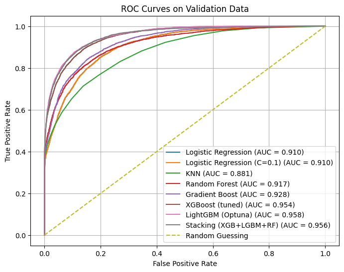

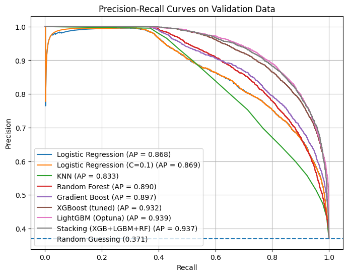

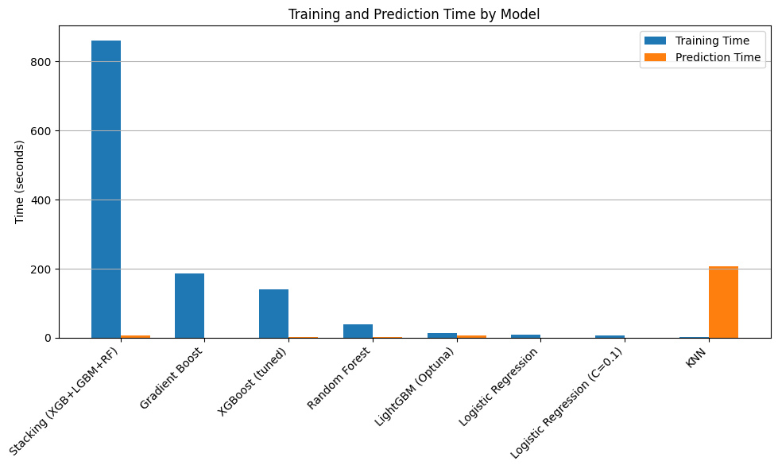

```
                         Model  Validation Accuracy  Validation AUC  \
0            LightGBM (Optuna)             0.889389        0.958206
1       Stacking (XGB+LGBM+RF)             0.888185        0.955863
2              XGBoost (tuned)             0.880542        0.953582
3               Gradient Boost             0.853217        0.928237
4                Random Forest             0.776789        0.917231
5  Logistic Regression (C=0.1)             0.829451        0.910238
6          Logistic Regression             0.829974        0.910186
7                          KNN             0.807098        0.880991

   Validation AP  Training Time (s)  Prediction Time (s)
0       0.939083          13.253330             6.478119
1       0.936927         860.670369             7.414712
2       0.931588         140.651667             2.276553
3       0.896975         186.195160             0.509318
4       0.889925          38.080606             1.138932
5       0.868785           6.532904             0.128499
6       0.867986           9.983390             0.072164
7       0.832615           2.293277           206.558805
```

```python
# final results
plot_roc_curves(results)
plot_pr_curves(results, y_val)
plot_model_times(results)

results_df = results_table(results)
print(results_df)
```

Model selection & tuning: I started with baseline models (logistic regression (plus adding regularization), KNN) and then moved to more complex tree-based models (Random Forests, Gradient Boosting, XGBoost, LightGBM). I used a validation split with ROC-AUC as the main metric and compared PR/ROC curves. For tuning, I applied manual tuning (e.g., depth, estimators), early stopping for XGBoost to find optimal trees, and Optuna for LightGBM to systematically search hyperparameters. I also tried a stacking ensemble combining top models. I had tried a grid search at first for Random Forest but due to computational limits, was unable to complete it, which is why I pivoted to trying gradient boosting models instead.

Best model & selection: LightGBM (Optuna) performed best (highest AUC ≈ 0.958 and strongest PR curve), closely followed by stacking and XGBoost. I selected it based on consistently highest validation AUC and better precision-recall tradeoff across thresholds, indicating stronger performance on imbalanced data.

## 1.3 Applying Model

**Retrain models on full data and generate Kaggle submissions**

```python
X_train_full = add_features(X_train_ohe).copy()
X_test_full = add_features(X_test_ohe).copy()

imputer_full = SimpleImputer(strategy="median")

X_train_full_imputed = pd.DataFrame(
    imputer_full.fit_transform(X_train_full),
    columns=X_train_full.columns,
    index=X_train_full.index
)

X_test_full_imputed = pd.DataFrame(
    imputer_full.transform(X_test_full),
    columns=X_test_full.columns,
    index=X_test_full.index
)

scaler_full = StandardScaler()

X_train_full_scaled = pd.DataFrame(
    scaler_full.fit_transform(X_train_full_imputed),
    columns=X_train_full_imputed.columns,
    index=X_train_full_imputed.index
)

X_test_full_scaled = pd.DataFrame(
    scaler_full.transform(X_test_full_imputed),
    columns=X_test_full_imputed.columns,
    index=X_test_full_imputed.index
)

log_reg_final = LogisticRegression(max_iter=2000, random_state=42)
log_reg_final.fit(X_train_full_scaled, y_train)
log_reg_test_probs = log_reg_final.predict_proba(X_test_full_scaled)[:, 1]
create_submission(log_reg_test_probs, "/content/drive/MyDrive/Duke-MIDS/ML/HW5/data/logistic_regression_submission.csv")

log_reg_l2_stronger_final = LogisticRegression(C=0.1, max_iter=2000, random_state=42)
log_reg_l2_stronger_final.fit(X_train_full_scaled, y_train)
log_reg_l2_stronger_test_probs = log_reg_l2_stronger_final.predict_proba(X_test_full_scaled)[:, 1]
create_submission(log_reg_l2_stronger_test_probs, "/content/drive/MyDrive/Duke-MIDS/ML/HW5/data/logistic_regression_c01_submission.csv")

knn_final = KNeighborsClassifier(n_neighbors=15)
knn_final.fit(X_train_full_scaled, y_train)
knn_test_probs = knn_final.predict_proba(X_test_full_scaled)[:, 1]
create_submission(knn_test_probs, "/content/drive/MyDrive/Duke-MIDS/ML/HW5/data/knn_submission.csv")


gb_final = GradientBoostingClassifier(
    n_estimators=200,
    learning_rate=0.05,
    max_depth=3,
    subsample=0.8,
    random_state=42
)
gb_final.fit(X_train_full_imputed, y_train)
gb_test_probs = gb_final.predict_proba(X_test_full_imputed)[:, 1]
create_submission(gb_test_probs, "/content/drive/MyDrive/Duke-MIDS/ML/HW5/data/gradient_boost_submission.csv")

print("Saved submissions:")
print("./data/logistic_regression_submission.csv")
print("./data/logistic_regression_c01_submission.csv")
print("./data/knn_submission.csv")
print("./data/gradient_boost_submission.csv")
```

```
Saved submissions:
./data/logistic_regression_submission.csv
./data/logistic_regression_c01_submission.csv
./data/knn_submission.csv
./data/gradient_boost_submission.csv
```

```python
rf_final = RandomForestClassifier(
    n_estimators=300,
    max_depth=12,
    min_samples_split=10,
    random_state=42,
    n_jobs=-1
)
rf_final.fit(X_train_full_imputed, y_train)
rf_test_probs = rf_final.predict_proba(X_test_full_imputed)[:, 1]
create_submission(rf_test_probs, "/content/drive/MyDrive/Duke-MIDS/ML/HW5/data/random_forest_submission.csv")
```

```python
xgb_final = XGBClassifier(
    n_estimators=500,
    learning_rate=0.05,
    max_depth=6,
    random_state=42,
    n_jobs=-1,
    verbosity=0,
    eval_metric="auc",
)
xgb_final.fit(X_train_full_imputed, y_train)
xgb_test_probs = xgb_final.predict_proba(X_test_full_imputed)[:, 1]
create_submission(xgb_test_probs,
    "/content/drive/MyDrive/Duke-MIDS/ML/HW5/data/xgboost_simple_submission.csv")
print("Saved xgboost_simple_submission.csv")
```

[output not shown]

### New Model Submissions

```python
# retrain XGBoost on all data and create submission
X_train_full_imp = add_features(X_train_ohe).copy()
X_test_full_imp  = add_features(X_test_ohe).copy()

_imp = SimpleImputer(strategy="median")
X_train_full_imp = pd.DataFrame(
    _imp.fit_transform(X_train_full_imp),
    columns=X_train_full_imp.columns)
X_test_full_imp = pd.DataFrame(
    _imp.transform(X_test_full_imp),
    columns=X_test_full_imp.columns)

xgb_final = XGBClassifier(
    n_estimators=800, learning_rate=0.05, max_depth=6,
    subsample=0.8, colsample_bytree=0.8, min_child_weight=3,
    gamma=0.1, reg_alpha=0.1, reg_lambda=1.0,
    use_label_encoder=False, eval_metric="auc",
    random_state=42, n_jobs=-1, verbosity=0,
)
xgb_final.fit(X_train_full_imp, y_train)
xgb_test_probs = xgb_final.predict_proba(X_test_full_imp)[:, 1]
create_submission(xgb_test_probs,
    "/content/drive/MyDrive/Duke-MIDS/ML/HW5/data/xgboost_submission.csv")
print("Saved xgboost_submission.csv")
```

```
Saved xgboost_submission.csv
```

```python
# retrain light GBM on all data and create submission
lgbm_final = lgb.LGBMClassifier(
    **study.best_params, random_state=42, n_jobs=-1, verbosity=-1,
)
lgbm_final.fit(X_train_full_imp, y_train)
lgbm_test_probs = lgbm_final.predict_proba(X_test_full_imp)[:, 1]
create_submission(lgbm_test_probs,
    "/content/drive/MyDrive/Duke-MIDS/ML/HW5/data/lightgbm_submission.csv")
print("Saved lightgbm_submission.csv")
```

```
Saved lightgbm_submission.csv
```

```python
# retrain stacking on all data and create submission
stack_final = StackingClassifier(
    estimators=[
        ("xgb", XGBClassifier(
            n_estimators=800, learning_rate=0.05, max_depth=6,
            subsample=0.8, colsample_bytree=0.8, min_child_weight=3,
            gamma=0.1, reg_alpha=0.1, reg_lambda=1.0,
            use_label_encoder=False, eval_metric="auc",
            random_state=42, n_jobs=-1, verbosity=0,
        )),
        ("lgbm", lgb.LGBMClassifier(
            **study.best_params, random_state=42, n_jobs=-1, verbosity=-1,
        )),
        ("rf", RandomForestClassifier(
            n_estimators=300, max_depth=12, min_samples_split=10,
            random_state=42, n_jobs=-1,
        )),
    ],
    final_estimator=LR(C=1.0, max_iter=1000),
    cv=5,
    stack_method="predict_proba",
    n_jobs=-1,
)
stack_final.fit(X_train_full_imp, y_train)
stack_test_probs = stack_final.predict_proba(X_test_full_imp)[:, 1]
create_submission(stack_test_probs,
    "/content/drive/MyDrive/Duke-MIDS/ML/HW5/data/stacking_submission.csv")
print("Saved stacking_submission.csv")
```

[output not shown]

# Exercise 2: Clustering

## 2.1: K Means

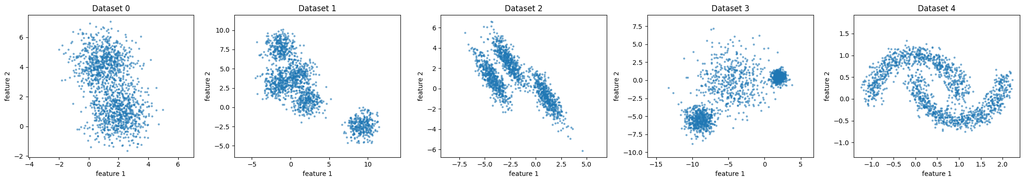

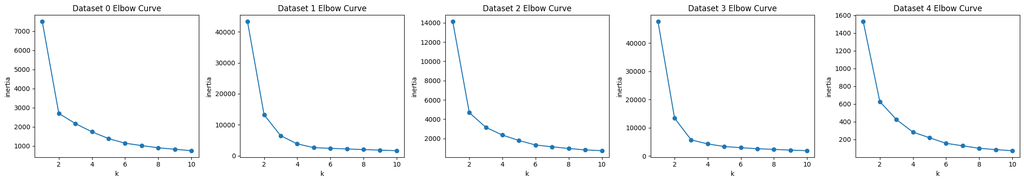

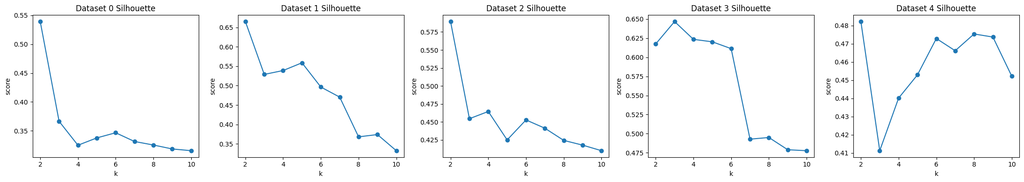

```
{0: 2, 1: 2, 2: 2, 3: 3, 4: 2}
```

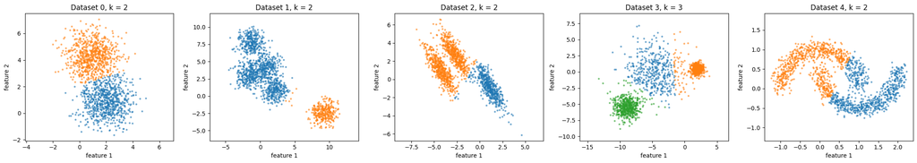

```python
################################
# Load the data
################################
import os
import numpy as np
import matplotlib.pyplot as plt
from sklearn.datasets import make_blobs, make_moons

# Create / load the datasets:
n_samples = 1500
X0, _ = make_blobs(n_samples=n_samples, centers=2, n_features=2, random_state=0)
X1, _ = make_blobs(n_samples=n_samples, centers=5, n_features=2, random_state=0)

random_state = 170
X, y = make_blobs(n_samples=n_samples, random_state=random_state, cluster_std=1.3)
transformation = [[0.6, -0.6], [-0.2, 0.8]]
X2 = np.dot(X, transformation)
X3, _ = make_blobs(n_samples=n_samples, cluster_std=[1.0, 2.5, 0.5], random_state=random_state)
X4, _ = make_moons(n_samples=n_samples, noise=.12)

X = [X0, X1, X2, X3, X4]
# The datasets are X[i], where i ranges from 0 to 4


################################
# Code to plot clusters
################################
def plot_cluster(ax, data, cluster_assignments):
    '''Plot two-dimensional data clusters

    Parameters
    ----------
    ax : matplotlib axis
        Axis to plot on
    data : list or numpy array of size [N x 2]
        Clustered data
    cluster_assignments : list or numpy array [N]
        Cluster assignments for each point in data

    '''
    clusters = np.unique(cluster_assignments)
    n_clusters = len(clusters)
    for ca in clusters:
        kwargs = {}
        if ca == -1:
            # if samples are not assigned to a cluster (have a cluster assignment of -1, color them gray)
            kwargs = {'color':'gray'}
            n_clusters = n_clusters - 1
        ax.scatter(data[cluster_assignments==ca, 0], data[cluster_assignments==ca, 1],s=5,alpha=0.5, **kwargs)
        ax.set_xlabel('feature 1')
        ax.set_ylabel('feature 2')
        ax.set_title(f'No. Clusters = {n_clusters}')
        ax.axis('equal')

# scatter plot each dataset
fig, axes = plt.subplots(1, 5, figsize=(22, 4))
for i, data in enumerate(X):
    axes[i].scatter(data[:, 0], data[:, 1], s=5, alpha=0.5)
    axes[i].set_title(f"Dataset {i}")
    axes[i].set_xlabel("feature 1")
    axes[i].set_ylabel("feature 2")
    axes[i].axis("equal")
plt.tight_layout()
plt.show()

from sklearn.cluster import KMeans, DBSCAN, SpectralClustering
from sklearn.metrics import silhouette_score

k_values = range(1, 11)
inertias = {}

fig, axes = plt.subplots(1, 5, figsize=(22, 4))
for i, data in enumerate(X):
    dataset_inertias = []
    for k in k_values:
        km = KMeans(n_clusters=k, random_state=0, n_init=10)
        km.fit(data)
        dataset_inertias.append(km.inertia_)
    inertias[i] = dataset_inertias

    axes[i].plot(list(k_values), dataset_inertias, marker='o')
    axes[i].set_title(f"Dataset {i} Elbow Curve")
    axes[i].set_xlabel("k")
    axes[i].set_ylabel("inertia")
plt.tight_layout()
plt.show()

from sklearn.metrics import silhouette_score
from sklearn.cluster import KMeans

k_values = range(2, 11)  # silhouette not defined for k=1
silhouette_scores = {}

fig, axes = plt.subplots(1, 5, figsize=(22, 4))

for i, data in enumerate(X):
    scores = []

    for k in k_values:
        km = KMeans(n_clusters=k, random_state=0, n_init=10)
        labels = km.fit_predict(data)
        score = silhouette_score(data, labels)
        scores.append(score)

    silhouette_scores[i] = scores

    axes[i].plot(list(k_values), scores, marker='o')
    axes[i].set_title(f"Dataset {i} Silhouette")
    axes[i].set_xlabel("k")
    axes[i].set_ylabel("score")

plt.tight_layout()
plt.show()

best_k_silhouette = {}

for i in range(len(X)):
    scores = silhouette_scores[i]
    best_k = list(k_values)[np.argmax(scores)]
    best_k_silhouette[i] = best_k

print(best_k_silhouette)

fig, axes = plt.subplots(1, 5, figsize=(22, 4))

for i, data in enumerate(X):
    k = best_k_silhouette[i]
    km = KMeans(n_clusters=k, random_state=0, n_init=10)
    labels = km.fit_predict(data)

    plot_cluster(axes[i], data, labels)
    axes[i].set_title(f"Dataset {i}, k = {k}")

plt.tight_layout()
plt.show()
```

**Interpretation:**

From the elbow curves for each dataset (dataset 0, 1, 2, 4), the elbow appears at k=2 (except for dataset 3 which performed better with k=3 clusters), which indicates this is where the inertia begins to have diminishing returns as we increase number of clusters, and this value of k could be a good balance.

## 2.2: DBSCAN

```python
# change  eps and min_samples parameters to get as close as you can to having the same number of clusters as your choices with K-means
from sklearn.cluster import DBSCAN

eps_values = np.linspace(0.1, 1.5, 15)
min_samples_values = [3, 5, 10, 15]

best_dbscan_params = {}
best_dbscan_labels = {}

# search for the best dbscan params to get as close to number of clusters as above
for i, data in enumerate(X):

    # number of cluster choices for each dataset from kmeans
    target_k = best_k_silhouette[i]
    best_diff = float("inf")
    best_params = None
    best_labels = None

    for eps in eps_values:
        for min_samples in min_samples_values:
            db = DBSCAN(eps=eps, min_samples=min_samples)
            labels = db.fit_predict(data)

            n_clusters = len(set(labels)) - (1 if -1 in labels else 0)
            diff = abs(n_clusters - target_k)

            if diff < best_diff:
                best_diff = diff
                best_params = (eps, min_samples, n_clusters)
                best_labels = labels

    best_dbscan_params[i] = best_params
    best_dbscan_labels[i] = best_labels

for i in range(len(X)):
    eps, min_samples, n_clusters = best_dbscan_params[i]
    print(f"Dataset {i}: target k = {best_k_silhouette[i]}, eps = {eps:.2f}, min_samples = {min_samples}, DBSCAN clusters = {n_clusters}")
```

```
Dataset 0: target k = 2, eps = 0.30, min_samples = 10, DBSCAN clusters = 2
Dataset 1: target k = 2, eps = 0.50, min_samples = 5, DBSCAN clusters = 2
Dataset 2: target k = 2, eps = 0.10, min_samples = 10, DBSCAN clusters = 2
Dataset 3: target k = 3, eps = 0.30, min_samples = 10, DBSCAN clusters = 3
Dataset 4: target k = 2, eps = 0.10, min_samples = 3, DBSCAN clusters = 2
```

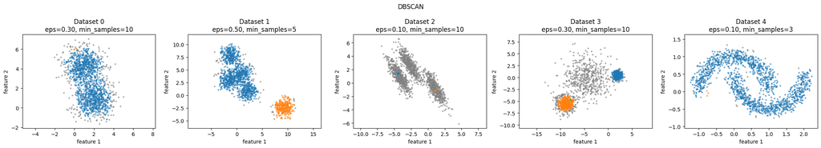

```python
fig, axes = plt.subplots(1, 5, figsize=(22, 4))
fig.suptitle("DBSCAN")

for i, data in enumerate(X):
    plot_cluster(axes[i], data, best_dbscan_labels[i])
    eps, min_samples, n_clusters = best_dbscan_params[i]
    axes[i].set_title(f"Dataset {i}\neps={eps:.2f}, min_samples={min_samples}")

plt.tight_layout()
plt.show()
```

## 2.3: Spectral Clustering

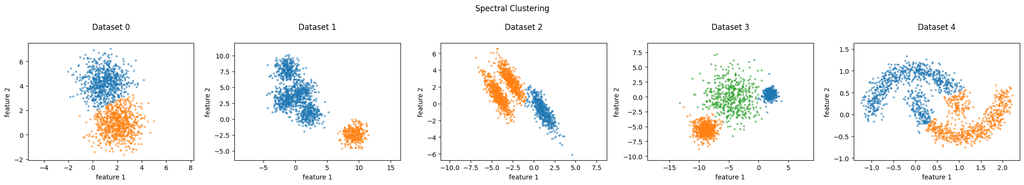

```python
#Apply Spectral Clustering. Select the same number of clusters as selected by k-means.
from sklearn.cluster import SpectralClustering

sc_labels = {}


for i, data in enumerate(X):

    # number of cluster choices for each dataset from kmeans
    target_k = best_k_silhouette[i]

    sc = SpectralClustering(
    n_clusters=target_k,
    affinity='nearest_neighbors',
    n_neighbors=10,
    random_state=42
)
    labels = sc.fit_predict(data)
    sc_labels[i] = labels


fig, axes = plt.subplots(1, 5, figsize=(22, 4))
fig.suptitle("Spectral Clustering")

for i, data in enumerate(X):
    plot_cluster(axes[i], data, sc_labels[i])
    axes[i].set_title(f"Dataset {i}\n")

plt.tight_layout()
plt.show()
```

# Exercise 3 - Dimensionality Reduction

```python
################################
# Load the data
################################
from sklearn import datasets
from sklearn.decomposition import PCA
from sklearn.manifold import TSNE

# load dataset
digits = datasets.load_digits()
n_sample = digits.target.shape[0]
n_feature = digits.images.shape[1] * digits.images.shape[2]
X_digits = np.zeros((n_sample, n_feature))
for i in range(n_sample):
    X_digits[i, :] = digits.images[i, :, :].flatten()
y_digits = digits.target
```

## 3.1: PCA

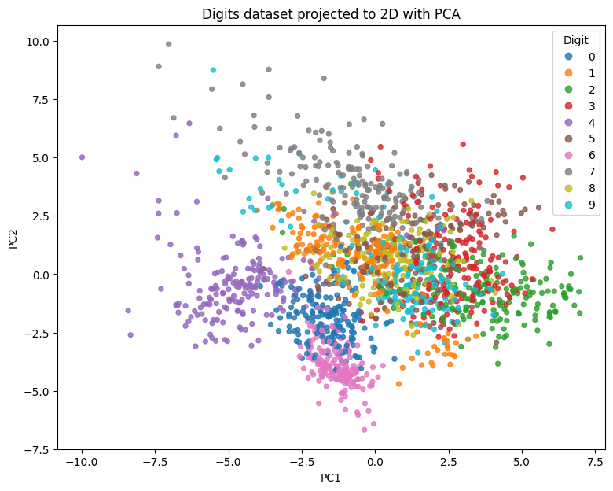

```python
from sklearn.preprocessing import StandardScaler
# standardize before PCA / t-SNE
scaler = StandardScaler()
X_scaled = scaler.fit_transform(X_digits)

# pca to 2d
pca_2d = PCA(n_components=2, random_state=42)
X_pca_2d = pca_2d.fit_transform(X_scaled)

plt.figure(figsize=(9, 7))
scatter = plt.scatter(X_pca_2d[:, 0], X_pca_2d[:, 1], c=y_digits, cmap="tab10", s=18, alpha=0.8)
plt.xlabel("PC1")
plt.ylabel("PC2")
plt.title("Digits dataset projected to 2D with PCA")
plt.legend(*scatter.legend_elements(), title="Digit")
plt.show()
```

I standardized the digits data before PCA because PCA is variance-based, so features on larger scales can dominate the principal components. After reducing the data to 2 dimensions, the PCA plot shows some visible grouping by digit, but several classes still overlap because projecting to only two linear components loses a large amount of information.

## 3.2: Plot Variance Explained

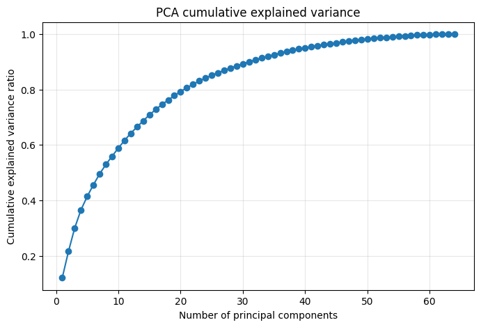

```
Fraction unexplained by first 2 PCs: 0.7840502949916721
```

```python
# cumulative explained variance
pca_full = PCA().fit(X_scaled)
cum_var = np.cumsum(pca_full.explained_variance_ratio_)

plt.figure(figsize=(8, 5))
plt.plot(range(1, len(cum_var) + 1), cum_var, marker="o")
plt.xlabel("Number of principal components")
plt.ylabel("Cumulative explained variance ratio")
plt.title("PCA cumulative explained variance")
plt.grid(True, alpha=0.3)
plt.show()

unexplained_2pc = 1 - cum_var[1]
print("Fraction unexplained by first 2 PCs:", unexplained_2pc)
```

The cumulative explained variance plot shows how much total variance is captured as more principal components are added. The fraction of variance unexplained by the first two principal components is 1 - cumulative variance at 2 PCs, which here is the printed value above (0.784). Since a large fraction of the variance is unexplained, the 2D PCA visualization cannot perfectly separate the digits, so overlap between classes is expected.

## 3.3: t-SNE

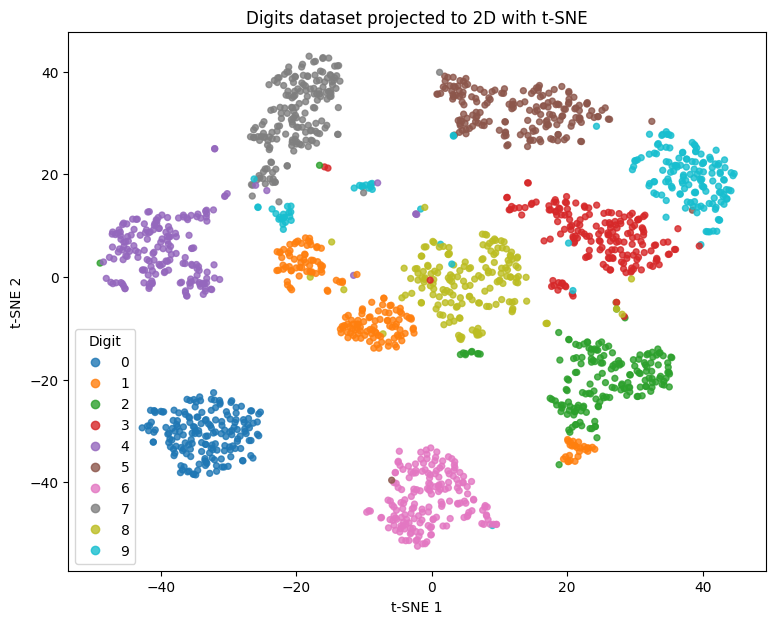

```python
# t-SNE to 2D
tsne = TSNE(n_components=2, perplexity=30, random_state=42, init="pca", learning_rate="auto")
X_tsne_2d = tsne.fit_transform(X_scaled)

plt.figure(figsize=(9, 7))
scatter = plt.scatter(X_tsne_2d[:, 0], X_tsne_2d[:, 1], c=y_digits, cmap="tab10", s=18, alpha=0.8)
plt.xlabel("t-SNE 1")
plt.ylabel("t-SNE 2")
plt.title("Digits dataset projected to 2D with t-SNE")
plt.legend(*scatter.legend_elements(), title="Digit")
plt.show()
```

t-SNE gives a 2D embedding that is usually much better at separating the digit classes visually because it is able to preserve local neighborhood structure instead of maximizing global variance. In the t-SNE plot, the classes tend to form tighter and more distinct groups than in PCA.

## 3.4: Conclusion

TSNE clusters the data better than PCA because the dataset has non linear structure so PCA can't fully capture this wth only 2 linear components. PCA is faster and simpler however, with more interpretable explained variance whle TSNE is good for visualization but requires more computation. That is why in scikit learn, TSNE usualy has fit_transform and not a separate transform, as it does not provide a true transform for new points. The embedding comes from the full dataset so adding new points isn't added in the same way that PCA does.

```python
# !pip install -q nbconvert
# !jupyter nbconvert --to html HW5.ipynb --TemplateExporter.exclude_input_prompt=True
```

[output not shown]

[output cut: 136 more lines]

[output not shown]